# causality in linear regression framework

2024-03-26

Let’s check the data visually by plotting a graph. Also, it’s always better to check the data before we dive into regression! Written by Kaylee Cho

```r
#load the data
library(tidyverse)
progresa <- read_delim("/Users/kayleecho/Documents/School Work/Winter 2024/INFO371/dataset/progresa-sample.csv")
```

basic dataset checkup

```r
nrow(progresa) # 77250 rows(=cases)
```

```
## [1] 77250
```

```r
progresa %>%
  select(village) %>%
  unique() %>%
  count()  # 505 villages
```

```
## # A tibble: 1 × 1
##       n
##   <int>
## 1   505
```

```r
progresa %>%
  filter(poor == 'pobre') %>%
  count() # 65392 poor in progresa villages
```

```
## # A tibble: 1 × 1
##       n
##   <int>
## 1 65392
```

average schooling rate of poor household by villages for 1997 and 1998

```r
progresa %>%
  filter(year == 98) %>%
  filter(poor == "pobre") %>%
  drop_na(sc) %>%
  summarize(avg = mean(sc)) #avg schooling rate of the poor in 1998
```

```
## # A tibble: 1 × 1
##     avg
##   <dbl>
## 1 0.832
```

```r
progresa %>%
  filter(year == 97) %>%
  filter(poor == "pobre") %>%
  drop_na(sc) %>%
  summarize(avg = mean(sc)) #avg schooling rate of the poor in 1997
```

```
## # A tibble: 1 × 1
##     avg
##   <dbl>
## 1 0.820
```

the average schooling rate between progresa villages, and in non progresa villages in 1997 and 1998.

```r
progresa %>%
  filter(year == 98) %>%
  filter(progresa == "0") %>%
  filter(poor == "pobre") %>%
  group_by(village) %>%
  drop_na(sc) %>%
  summarize(avg = mean(sc)) #non-progres 1998: 80.8%
```

```
## # A tibble: 185 × 2
##    village   avg
##      <dbl> <dbl>
##  1       3 0.8
##  2      13 0.72
##  3      16 0.806
##  4      20 0.917
##  5      22 0.652
##  6      26 0.645
##  7      27 0.946
##  8      28 0.4
##  9      30 0.803
## 10      31 0.878
## # ℹ 175 more rows
```

```r
progresa %>%
  filter(year == 98) %>%
  filter(progresa == "basal") %>%
  filter(poor == "pobre") %>%
  group_by(village) %>%
  drop_na(sc) %>%
  summarize(avg = mean(sc)) #progres 1998: 84.6%
```

```
## # A tibble: 320 × 2
##    village   avg
##      <dbl> <dbl>
##  1       1 0.8
##  2       2 0.714
##  3       4 0.931
##  4       5 0.833
##  5       6 0.911
##  6       7 0.88
##  7       8 0.867
##  8       9 0.692
##  9      10 0.762
## 10      11 0.833
## # ℹ 310 more rows
```

```r
progresa %>%
  filter(year == 97) %>%
  filter(progresa == "0") %>%
  filter(poor == "pobre") %>%
  group_by(village) %>%
  drop_na(sc) %>%
  summarize(avg = mean(sc)) #non-progres 1997: 81.5%
```

```
## # A tibble: 185 × 2
##    village   avg
##      <dbl> <dbl>
##  1       3 0.933
##  2      13 0.743
##  3      16 0.794
##  4      20 0.959
##  5      22 0.667
##  6      26 0.862
##  7      27 0.766
##  8      28 0.647
##  9      30 0.793
## 10      31 0.884
## # ℹ 175 more rows
```

```r
progresa %>%
  filter(year == 97) %>%
  filter(progresa == "basal") %>%
  filter(poor == "pobre") %>%
  group_by(village) %>%
  drop_na(sc) %>%
  summarize(avg = mean(sc)) #progres 1997: 82.3%
```

```
## # A tibble: 320 × 2
##    village   avg
##      <dbl> <dbl>
##  1       1 0.752
##  2       2 0.682
##  3       4 0.917
##  4       5 0.96
##  5       6 0.965
##  6       7 0.917
##  7       8 0.711
##  8       9 0.857
##  9      10 0.784
## 10      11 0.751
## # ℹ 310 more rows
```

plot the graph of avg schooling rate in progresa and non-progresa villages of year 1997

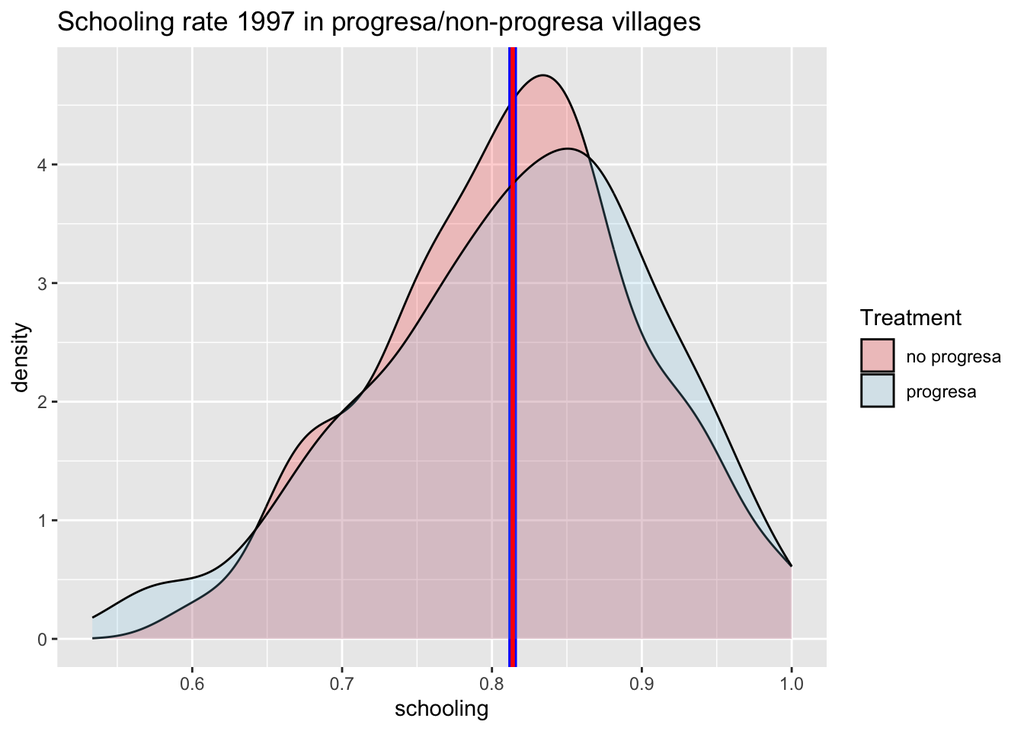

```r
non_progresa_97 <- progresa %>%
  filter(year == 97) %>%
  filter(poor == "pobre") %>%
  filter(progresa == "0") %>%
  drop_na(sc) %>%
  group_by(village) %>%
  summarise(schooling = mean(sc))

progresa_97 <- progresa %>%
  filter(year == 97) %>%
  filter(poor == "pobre") %>%
  filter(progresa == "basal") %>%
  drop_na(sc) %>%
  group_by(village) %>%
  summarise(schooling = mean(sc))

library(ggplot2)

ggplot() +
  geom_density(aes(schooling, fill = "no progresa"), alpha = .2, data = non_progresa_97) +
  geom_vline(xintercept = mean(non_progresa_97$schooling), colour="blue", size=2) +
  geom_density(aes(schooling, fill = "progresa"), alpha = .2, data = progresa_97) +
  geom_vline(xintercept = mean(progresa_97$schooling), colour="red", size=1) +
  scale_fill_manual(name = "Treatment", values = c("red", "sky blue")) +
  labs(title = "Schooling rate 1997 in progresa/non-progresa villages")
```

plot the graph of avg schooling rate in progresa and non-progresa villages of year 1998

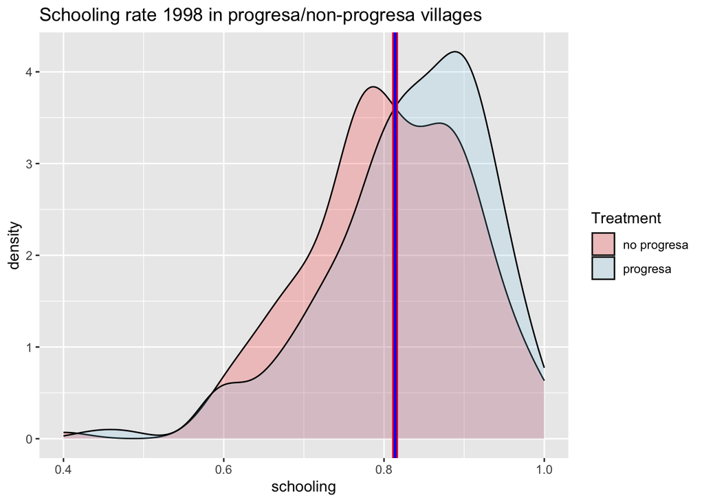

```r
non_progresa_98 <- progresa %>%
  filter(year == 98) %>%
  filter(poor == "pobre") %>%
  filter(progresa == "0") %>%
  drop_na(sc) %>%
  group_by(village) %>%
  summarise(schooling = mean(sc))

progresa_98 <- progresa %>%
  filter(year == 98) %>%
  filter(poor == "pobre") %>%
  filter(progresa == "basal") %>%
  drop_na(sc) %>%
  group_by(village) %>%
  summarise(schooling = mean(sc))

library(ggplot2)

ggplot() +
  geom_density(aes(schooling, fill = "no progresa"), alpha = .2, data = non_progresa_98) +
  geom_density(aes(schooling, fill = "progresa"), alpha = .2, data = progresa_98) +
  scale_fill_manual(name = "Treatment", values = c("red", "sky blue")) +
  geom_vline(xintercept = mean(non_progresa_97$schooling), color = "red", size=2) +
  geom_vline(xintercept = mean(progresa_97$schooling), color = "blue", size=1) +
  labs(title = "Schooling rate 1998 in progresa/non-progresa villages")
```